# De impact van het bespelen van een instrument op de wiskundige geletterdheid

Analyse resultaten

Arshad Aysha, Bouazzaoui Houssam, Moons Sebastiaan, Stevens Bram, Vanhoucke Dré

## Data inlezen

We gebruiken de Tidyverse functies om het CSV-bestand in te lezen.We hebben alleen de nodige kolommen toegevoegd die nodig zijn voor onze analyse- en visualisatietechnieken. Met het commando `attach(math_prof)` hebben we ervoor gezorgd dat we niet met de $-teken moeten werken.

```r
math_prof <- read_csv('../data/npe-1920-wiskundige-geletterdheid.csv')[,c('MusicalInstrument','MusicEducation','MusicYears','SheetMusic','MathPrep','SecondaryMathResults','GradeMath4IT','GradePOD1')]
attach(math_prof)
```

## Verband tussen GradeMath4IT en MusicalInstrument

GradeMath4IT: Kwantitatief  
MusicalInstrument: Kwalitatief  
AnalyseTechniek: t-toets voor 2 steekproeven

```r
controle<-GradeMath4IT[MusicalInstrument=='Nee']
interventie<-GradeMath4IT[!is.na(MusicalInstrument)||MusicalInstrument!='Nee']
t.test(controle,interventie,alternative = 'less')
```

```
##
##  Welch Two Sample t-test
##
## data:  controle and interventie
## t = -0.2572, df = 300.74, p-value = 0.3986
## alternative hypothesis: true difference in means is less than 0
## 95 percent confidence interval:
##       -Inf 0.4499085
## sample estimates:
## mean of x mean of y
##  11.99306  12.07614
```

De p-waarde, 0,3986, ligt duidelijk boven het significantieniveau(niet expliciet opgegeven, dus werd de standaardwaarde α = 0,05 gebruikt). We mogen de nullhypothese niet verwerpen en besluiten dat er mogelijks een verband is.

Visualisatietechniek: Boxplot

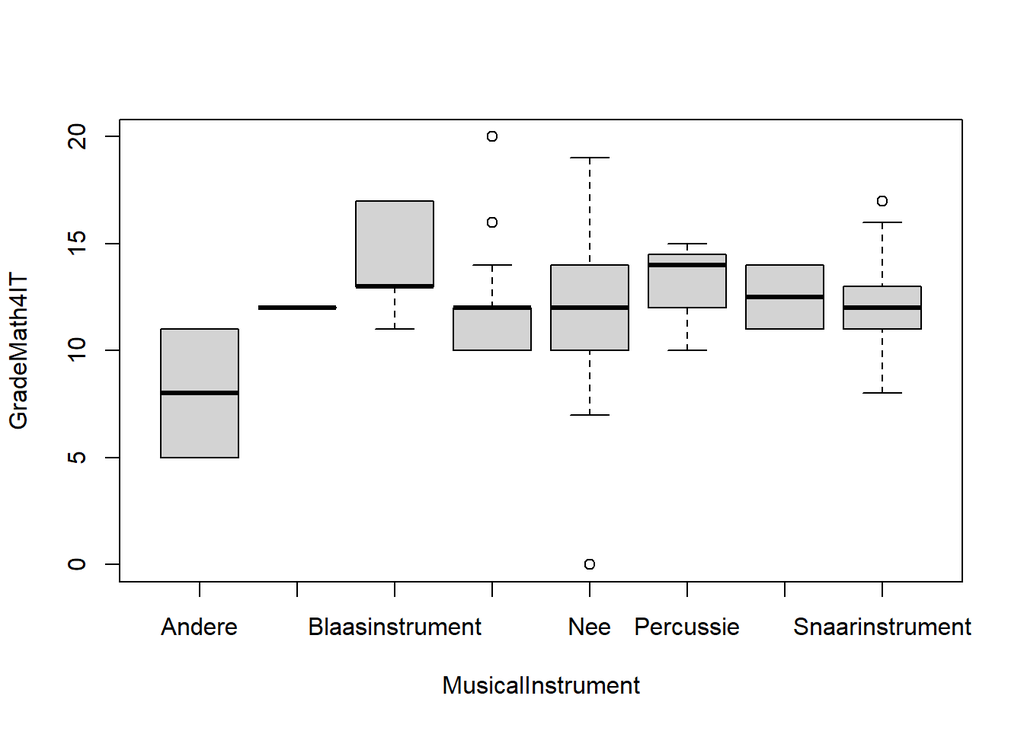

```r
boxplot(GradeMath4IT ~ MusicalInstrument)
```

## Verband tussen GradePOD1 en MusicEducation

GradePOD1: Kwantitatief  
MusicEducation: Kwalitatief  
AnalyseTechniek: t-toets voor 2 steekproeven

```r
controle1<-GradePOD1[is.na(MusicEducation)]
interventie1<-GradePOD1[!is.na(MusicEducation)]
t.test(controle1,interventie1,alternative = 'less')
```

```
##
##  Welch Two Sample t-test
##
## data:  controle1 and interventie1
## t = -0.49537, df = 87.753, p-value = 0.3108
## alternative hypothesis: true difference in means is less than 0
## 95 percent confidence interval:
##       -Inf 0.4614975
## sample estimates:
## mean of x mean of y
##  12.38411  12.58000
```

De p-waarde, 0,3108, ligt duidelijk boven het significantieniveau(niet expliciet opgegeven, dus werd de standaardwaarde α = 0,05 gebruikt). We mogen de nullhypothese niet verwerpen en besluiten dat er mogelijks een verband is.

Visualisatietechniek: Boxplot

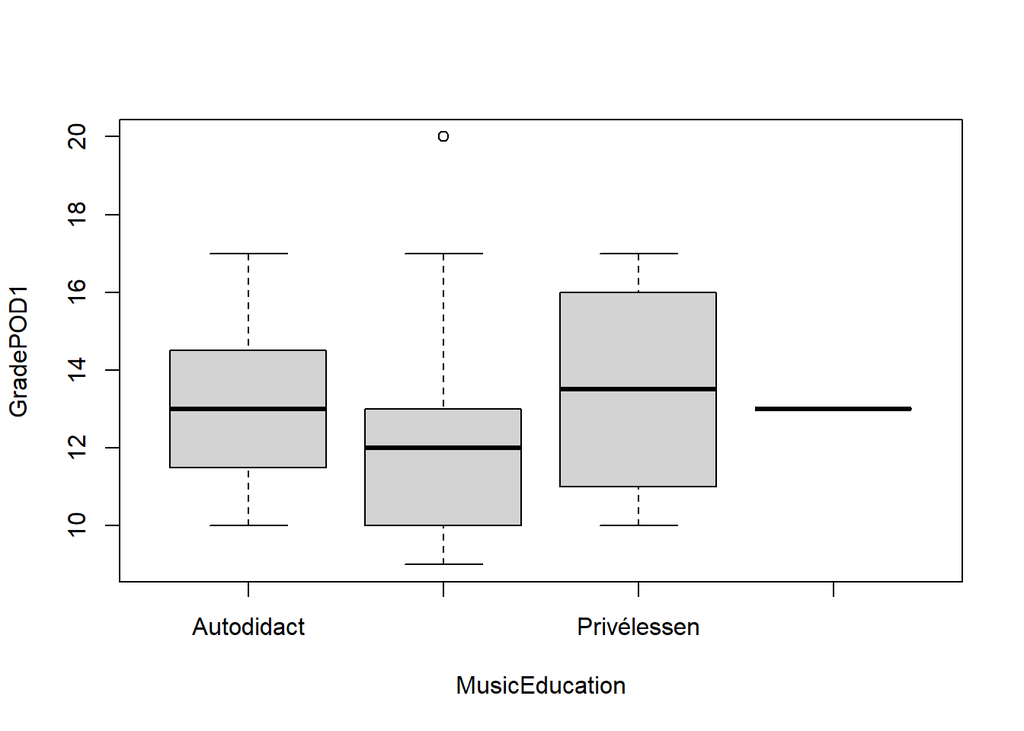

```r
boxplot(GradePOD1 ~ MusicEducation)
```

## Verband tussen SecondaryMathResults en SheetMusic

SecondaryMathResults: Kwantitatief  
SheetMusic: Kwalitatief  
AnalyseTechniek: t-toets voor 2 steekproeven

```r
controle2<-SecondaryMathResults[SheetMusic=='Nee']
interventie2<-SecondaryMathResults[SheetMusic=='Ja']
t.test(controle2,interventie2,alternative = 'less')
```

```
##
##  Welch Two Sample t-test
##
## data:  controle2 and interventie2
## t = -1.3874, df = 86.003, p-value = 0.08445
## alternative hypothesis: true difference in means is less than 0
## 95 percent confidence interval:
##        -Inf 0.07942342
## sample estimates:
## mean of x mean of y
##  6.416149  6.816327
```

De p-waarde, 0,08445, ligt boven het significantieniveau(niet expliciet opgegeven, dus werd de standaardwaarde α = 0,05 gebruikt). We mogen de nullhypothese niet verwerpen en besluiten dat er mogelijks een verband is.

Visualisatietechniek: Boxplot

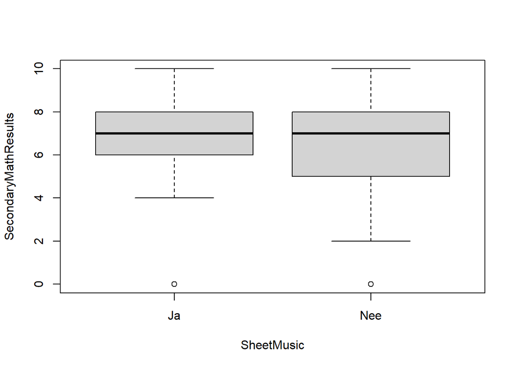

```r
boxplot(SecondaryMathResults ~ SheetMusic)
```

## Verband tussen MathPrep en MusicYears

MathPrep: Kwantitatief  
MusicYears: Kwantitatief  
AnalyseTechniek: Regressie

```r
MathPrep_MusicYears_lm <- lm(MathPrep ~ MusicYears)
MathPrep_MusicYears_lm
```

```
##
## Call:
## lm(formula = MathPrep ~ MusicYears)
##
## Coefficients:
## (Intercept)   MusicYears
##     5.63608     -0.03516
```

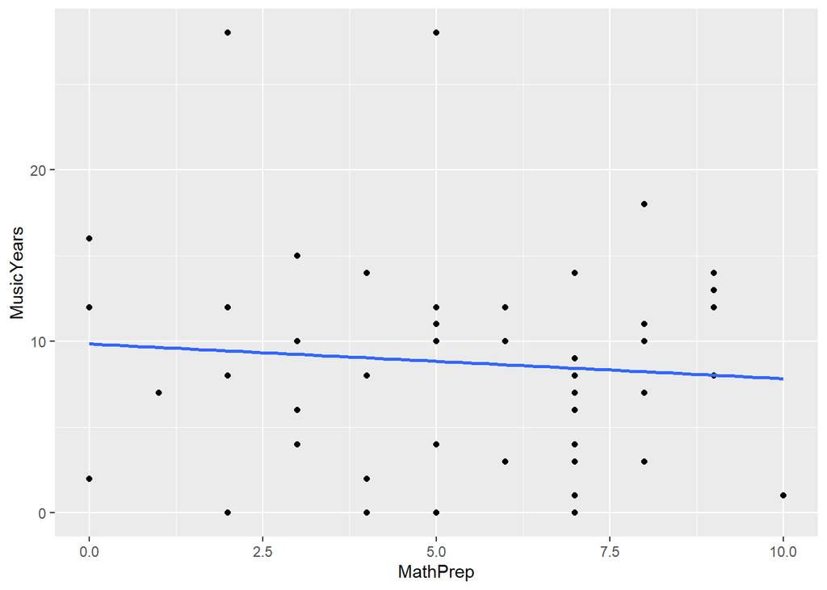

```r
ggplot(data = math_prof, mapping = aes(x = MathPrep , y = MusicYears)) +
  geom_point() +
  geom_smooth(method = "lm" ,formula = y ~ x, se = FALSE)
```

Met deze tabel willen we laten inzien dat we uit dit verband geen conlusies kunnen trekken omdat er te weinig observaties zijn.

```r
AantalGeenMuziekJaren<-length(which(MusicYears==0))
AantalMetMuziekJaren<-length(which(MusicYears>0))
AantalGeenAntwoord<-length(which(is.na(MusicYears)))
TotaalAantal<-length(MusicYears)
PercentAantalGeenMuziekJaren<-format(round(length(which(MusicYears==0))/length(MusicYears)*100,2),nsmall=2)
PercentAantalMetMuziekJaren<-format(round(length(which(MusicYears>0))/length(MusicYears)*100,2),nsmall=2)
PercentAantalGeenAntwoord<-format(round(length(which(is.na(MusicYears)))/length(MusicYears)*100,2),nsmall=2)
deelnameData<-matrix(c(AantalGeenMuziekJaren,PercentAantalGeenMuziekJaren,AantalMetMuziekJaren,PercentAantalMetMuziekJaren,AantalGeenAntwoord,PercentAantalGeenAntwoord,TotaalAantal,''),ncol = 2,byrow=TRUE)
colnames(deelnameData)<-c("Aantal antwoorden","Aantal antwoorden %")
rownames(deelnameData)<-c("Mensen zonder muziekverleden","Mensen met muziekverleden","geen antwoord","Totaal")
deelnameData<-as.table(deelnameData)
deelnameData
```

```
##                              Aantal antwoorden Aantal antwoorden %
## Mensen zonder muziekverleden 4                 1.84
## Mensen met muziekverleden    51                23.50
## geen antwoord                162               74.65
## Totaal                       217
```